# People

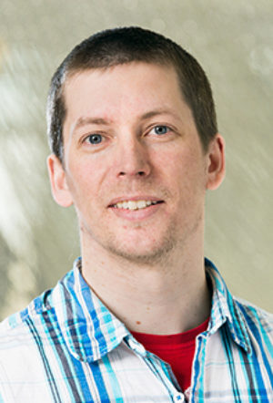

Mark D Robinson

Twitter [@markrobinsonca](https://twitter.com/markrobinsonca)  
GitHub markrobinsonuzh  
[Google Scholar](https://scholar.google.ch/citations?user=XPfrRQEAAAAJ)

My research interests are diverse, but more-or-less encompass the general application of statistical methods and data science to experimental data with biological applications. Often, this is within the context of genomics data types, but we are interested in methodological challenges and robust solutions in data, generally. We also try to be modern scientists, with a focus on reproducibility (repos for code) and open science (preprints).

PhD in Medical Biology (2008), University of Melbourne (Walter and Eliza Hall Institute)  
MSc in Statistics (2001), University of British Columbia  
BSc in Applied Mathematics and Statistics (1999), University of Guelph

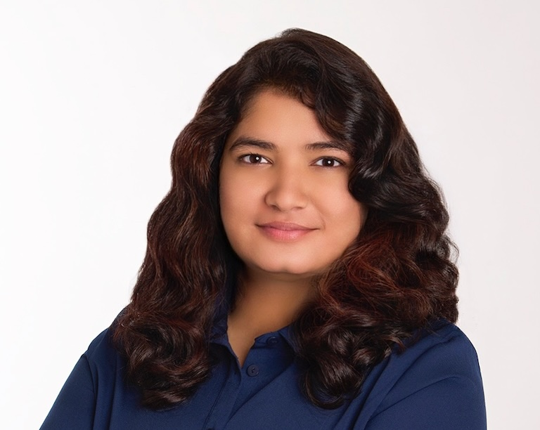

Meenu Bhati

[Google Scholar](https://scholar.google.com/citations?user=l2kH-6EAAAAJ&hl=en&authuser=1)

My research focuses on understanding genome biology across species from functional and evolutionary perspectives. I integrate genetics and multi-omics approaches to investigate regulatory mechanisms within the non-coding genome, with particular emphasis on long non-coding RNAs. Through this work, I aim to advance the functional interpretation of regulatory variation associated with complex traits while developing computational resources for the broader scientific community.

PhD in Animal Genomics (2024), ETH Zurich, Switzerland  
MSc in Animal Genomics & Breeding (2017), Wageningen University, Netherlands  
BVSc&AH in Veterinary & Animal Sciences (2014), Rajasthan University of Veterinary and Animal Sciences, India

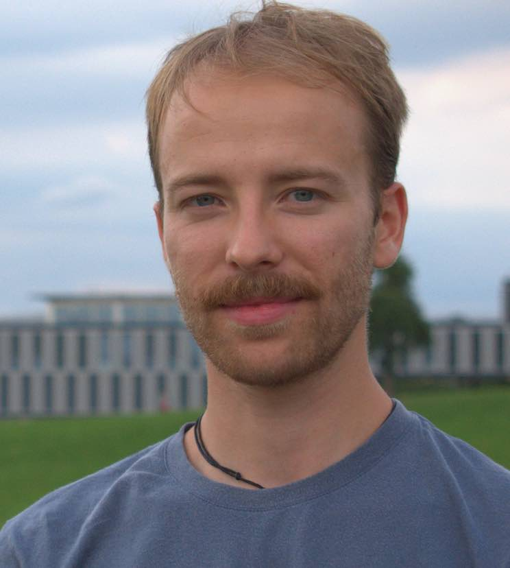

Emanuel Sonder

Twitter [@EmanuelSonder](https://twitter.com/EmanuelSonder)  
GitHub emsonder

After finishing my Master’s Thesis in the Robinson Group, I started a shared PhD position with the [Schratt lab](https://schrattlab.ethz.ch/the-group.html). I have a general interest in the analysis of epigenetic data (ATAC-seq, WGBS). My PhD project is focused on the reverse engineering of cell type-specific transcriptional networks by integrating different data modalities. The overarching goal is to provide insights in brain cell type specific responses to different stressors when compared with neuronal activity.

MSc in Computational Biology and Bioinformatics (2021), ETH Zürich, University of Zürich  
BSc in Biology (2018), ETH Zürich

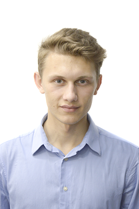

Vladyslav Korobeynyk

GitHub vkorobeynyk

I did my master thesis in single cell analysis of the adult mouse hippocampus in Jessberger Lab, HIFO, UZH. Shortly after, I started working as an intern in Systems Biology group at Roche, where I gained experience in ML and different type of sequencing technologies. Currently I am doing a shared PhD with Jessberger Lab, where my project is based on using single-cell and spatial transcriptomics data to identify molecular changes, mainly in the neurogenic niche, that drive neurogenesis to decline with age.

MSc in Biochemistry (2021), University of Zurich  
BSc in Biochemistry (2017), University Nova of Lisbon

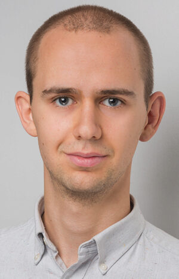

David Wissel

I am a shared PhD student between the Robinson Lab at UZH and the BoevaLab at ETH. I am broadly interested in survival analysis, single-cell and spatial transcriptomics as well as applications of machine learning to all of these.

MSc Statistics (2021), ETH Zurich  
BSc Business Administration (2019), Free University of Berlin

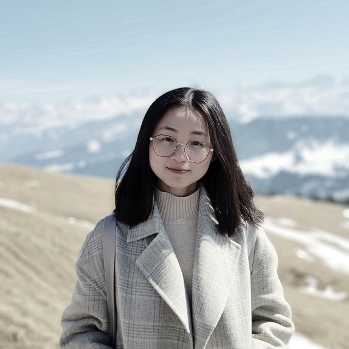

Siyuan Luo

I’m an external PhD student from the [von Meyenn lab](https://epigenetics.ethz.ch/) with a background in computational biology and bioinformatics. During my master study, I worked on various topics including copy number variation and TCR/BCR repertoire analysis. Now I’m mainly interested in analyzing single-cell epigenetic data (ATAC-seq/CUT&Tag). My PhD is about methods for single-cell multi-omics data to reveal the interplay between the epigenetic layers and transcriptomics and provide insights for chronic diseases like obesity and ageing.

MSc in Computational Biology and Bioinformatics (2021), ETH Zürich, University of Zürich  
BSc in Biotechnology (2018), Harbin Institute of Technology

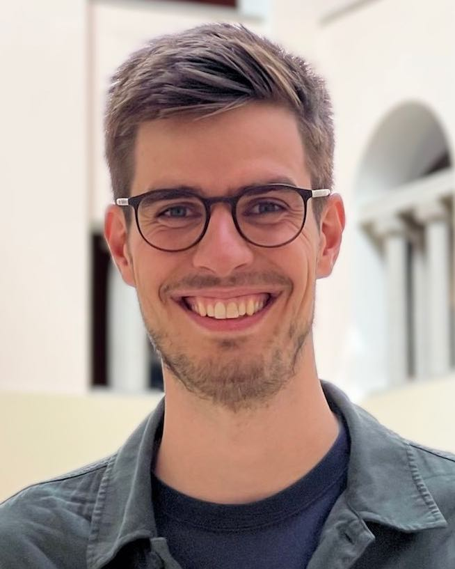

Martin Emons

I am a PhD student in the Robinson Group since 2022 in the Epidemiology and Biostatistics PhD program. My general interest lies in the development of methods for biological and biomedical data science. In my master studies I worked on various topics such as statistical analysis of temporal trends or survival analysis at Roche Diagnostics. Currently, I am interested in spatial transcriptomics and the challenges in this new field.

MSc in Computational Biology and Bioinformatics (2022), ETH Zürich, University of Zürich  
BSc in Biology (2019), University of Bern

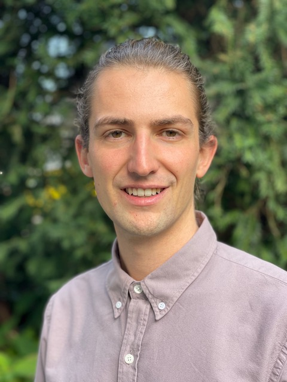

Samuel Gunz

Twitter [@samuelgunz](https://twitter.com/samuelgunz)  
GitHub sgunz

I am a PhD student in the Robinson lab as part of the Epidemiology and Biostatistics program of the Life Science Graduate School Zurich. During my past studies, I worked with all sorts of biological data, ranging from microbial community analysis to characterizing epigenetic modifications in cancer. During this time, I acknowledged the importance of having robust and reproducible tools in research and that my interest lies in developing such. My PhD project will focus on methods for analyzing spatial omics data.

MSc in Computational Biology and Bioinformatics (2022), ETH Zurich, University of Basel and University of Zurich  
BSc in Biology (2018), University of Zurich

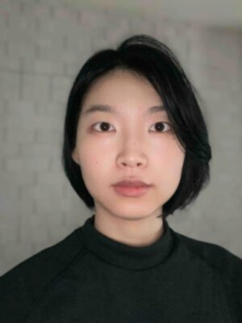

Peiying Cai

In February 2023, I started working as a PhD student in the Robinson lab. Previously, I worked on developing analysis tools and pipelines to identify spatially variable genes from spatial transcriptomics data. My PhD research will focus on the development of statistical methods in bioinformatics, mostly for single-cell RNA-seq and spatial transcriptomics data.

MSc in Biostatistics (2022), University of Zürich  
BSc of Science in Statistics (2019), Xiamen University

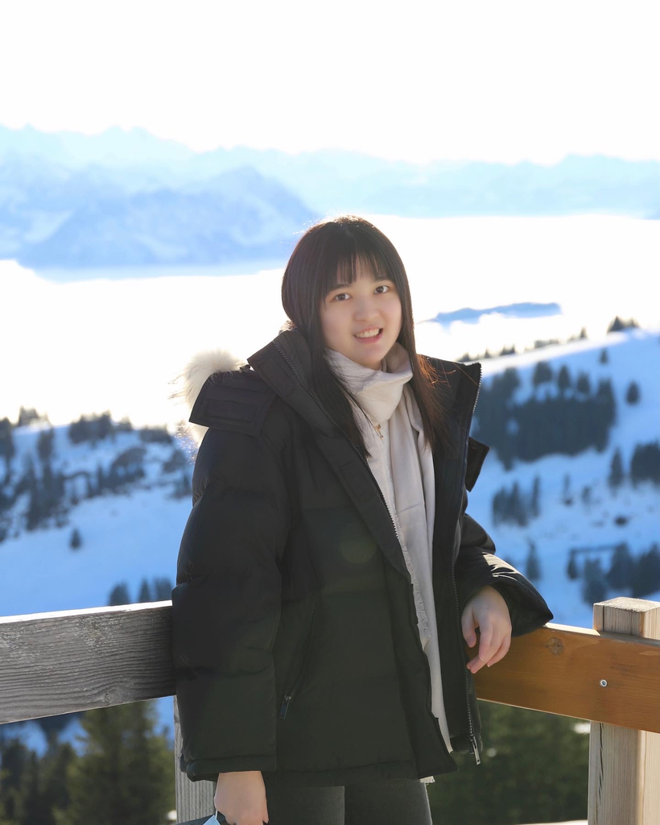

Jiayi Wang

[LinkedIn](https://www.linkedin.com/in/jiayi-wang-14a3261ba/)

After finishing an internship and my master thesis in the Robinson group, I joined as a PhD student. During this time I worked on disentangling type and state effects on expression variability to improve analysis and interpretability of scRNA-seq data and identifying motif accessibility changes in ATAC-seq data. My PhD project primarily focuses on data analysis of long-read scRNA data and image analysis.

MSc in Computational Biology and Bioinformatics (2024), ETH Zürich  
BSc in Biomedical Sciences (2021), University College London

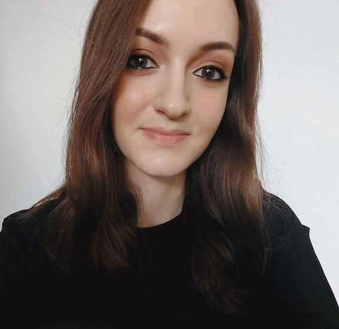

Maruša Koderman

I joined the Robinson lab as a PhD student in 2024. Prior to starting my PhD, I worked as in intern at Roche (Pharma Research and Early Development), where I focused on single-cell data analysis and construction of human brain cell type atlases. In my PhD, I am continuing this work by leveraging large-scale multimodal single-cell atlases to advance the development of in vitro model systems and investigate new potential drug targets.

MSc in Laboratory Biomedicine (2021), University of Ljubljana  
BSc in Laboratory Biomedicine(2017), University of Ljubljana

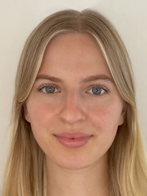

Pauline Busch

LinkedIn

I joined the Robinson lab as a PhD student at the end of 2024. My background is in biomedical research, with previous work focusing on pathophysiological processes in blood and brain. During my master’s studies I developed an interest in bioinformatics and during my PhD I aim to contribute to the development of methods for analyzing spatial transcriptomics data.

MSc in Molecular Life Sciences (2022), University of Hamburg  
BSc in Biology (2019), University of Hamburg

[figure not shown]

Ben Carrillo

PhD student at Robinson lab since Spring 2025. I am interested in building robust, composable tools for reproducible biomedical research. Working on tools for methods benchmarking.

MSc in Biostatistics and Bioinformatics (2023), Universitat Oberta de Catalunya

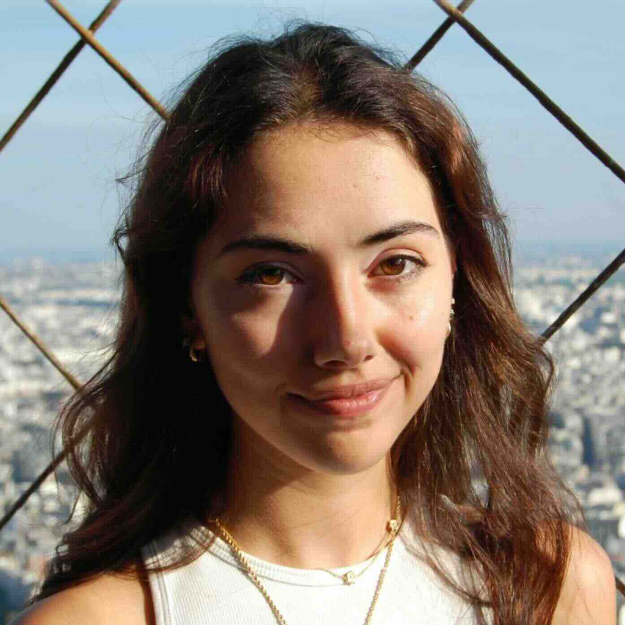

Noemi Loffredi

I am an external Master’s student of Biotechnology and Applied AI. I am currently working on my thesis at Robinson lab focusing on the analysis of spatial omics features, with the aim of evaluating their relevance in biological systems.

MSc in Biotechnology and Applied AI for Health, University of Pisa and Aix-Marseille University (ongoing)  
BSc in Biotechnology, University of Pisa(2024)

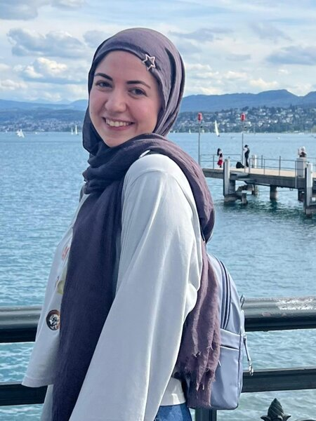

Elif Zeynep Demir

I am a visiting Master’s student in Bioengineering, with particular interests in single-cell transcriptomics and computational cancer biology. At the Robinson Lab, my work focuses on using OmniBenchmark to study how preprocessing and representation choices alter the geometry of single-cell RNA-seq data.

MSc in Bioengineering, Marmara University (ongoing)  
BSc in Molecular Biology and Genetics, Bahçeşehir University (2024)

## Alumni

- [Izaskun Mallona](https://izaskunmallona.org/) (Senior researcher)
- Daniel Incicau (research assistant)
- Reto Gerber (PhD Student; author of MIMIC among various other things)
- Pierre-Luc Germain (Shared postdoc; author of scDblFinder among various other things)
- Anna Schuster (MSc student)
- Sarusan Kathirchelvan (MSc student)
- Almut Lütge (PhD student; author of [CellMixS](https://www.bioconductor.org/packages/release/bioc/html/CellMixS.html); now Biomedical Data Engineer at [Swiss Data Science Center](https://datascience.ch))
- Anthony Sonrel (PhD student; now Bioinformatics Scientist @Idorsia)
- Yin Guo (visiting PhD student from Xi’an Jiaotong University)
- Helena Crowell (PhD student; author of [CATALYST](https://bioconductor.org/packages/release/bioc/html/CATALYST.html), [muscat](https://bioconductor.org/packages/release/bioc/html/muscat.html), [SpatialExperiment](https://www.bioconductor.org/packages/release/bioc/html/SpatialExperiment.html); now postdoc at [CNAG](https://www.cnag.eu/teams/genome-research-unit/single-cell-genomics-team))
- Stefan Milosavljevic (PhD student shared with Shimizu group; author of ARPEGGIO; now Biomedical Data Engineer at [Swiss Data Science Center](https://datascience.ch))
- Simone Tiberi (postdoc; author of [BANDITS](https://bioconductor.org/packages/release/bioc/html/BANDITS.html) and [distinct](https://bioconductor.org/packages/release/bioc/html/distinct.html); now Assistant Professor at Università di Bologna)
- Dominique Paul (research assistant)
- Hao Lyu (visiting PhD student)
- Elyas Heidari (Research assistant; author of SageNet; now PhD student at EMBL Heidelberg)
- Vladimir B. C. de Souza (PhD student; author of lrRNAseqVariantCalling)
- Imran Fanaswala (Research assistant; founder of [YugaCell](https://yugacell.com/))
- Stephan Schmeing (PhD student; author of ReSeq)
- Ahmad Al Ajami (MSc student)
- Kathi Hembach (PhD student; author of DISCERNS; co-author of ARMOR)
- Stephany Orjuela (PhD student; author of DAMEfinder; co-author of ARMOR; now Scientific software developer at [Oncobit](https://oncobit.com/))
- Will Macnair (Postdoc; author of [SampleQC](https://github.com/wmacnair/SampleQC/); now Data Scientist at [Hoffman La Roche](https://www.roche.ch/))
- Ruizhu (Fiona) Huang (PhD student; author of treeclimbR, [TreeSummarizeExperiment](https://www.bioconductor.org/packages/release/bioc/html/TreeSummarizedExperiment.html), co-author of ARMOR; now Biostatistician at Cardio-CARE)
- [Joanna Zyprych-Walczak](http://merlin.up.poznan.pl/kmmis2/index.php?id=158&id2=105) (visiting professor)
- [Charlotte Soneson](http://csoneson.github.io/) (postdoc, investigated [various](https://f1000research.com/articles/4-1521/) [aspects](https://genomebiology.biomedcentral.com/articles/10.1186/s13059-015-0862-3) of [RNA-seq](https://www.nature.com/articles/nmeth.4612) [data](http://www.life-science-alliance.org/content/2/1/e201800175) and [method](https://www.nature.com/articles/nmeth.3805) [benchmarking](https://academic.oup.com/bioinformatics/article/34/4/691/4345646); now at [FMI](https://www.fmi.ch))
- Helen Lindsay (postdoc, author of [CrispRVariants](https://bioconductor.org/packages/release/bioc/html/CrispRVariants.html); now at [EPFL](https://www.epfl.ch/))
- Charity Law (postdoc, worked on differential splicing; now at [WEHI](https://www.wehi.edu.au/))
- Andrea Riebler (postdoc, author of [BayMeth](https://genomebiology.biomedcentral.com/articles/10.1186/gb-2014-15-2-r35) in [Repitools](http://bioconductor.org/packages/release/bioc/html/Repitools.html) package; now at [NTNU](https://www.ntnu.edu/imf))
- Ian Morilla (postdoc, involved in differential expression analysis using de novo RNA-seq assemblies; now at [INSERM](https://www.inserm.fr/))
- [Lukas Weber](https://lmweber.github.io/) (PhD student, [compared CyTOF clustering algorithms](https://onlinelibrary.wiley.com/doi/full/10.1002/cyto.a.23030), author of [diffcyt](https://www.nature.com/articles/s42003-019-0415-5), reviewed [benchmarking](https://genomebiology.biomedcentral.com/articles/10.1186/s13059-019-1738-8); now at [JHU](https://www.jhsph.edu/departments/biostatistics/index.html))
- Xiaobei Zhou (PhD student; author of [edgeR robust](https://academic.oup.com/nar/article/42/11/e91/1427925))
- Malgorzata Nowicka (PhD student, author of DRIMSeq and [cytofWorkflow](https://bioconductor.org/packages/cytofWorkflow/); now at [Hoffman La Roche](https://www.roche.ch/))
- Hadi Gharibi (PhD student, analyzed BS-seq data; now at [Uni. Tehran](http://ut.ac.ir/en))
- Andrea Komljenovic (PhD student, analyzed DNA methylation data; now at [UNIL](https://www.unil.ch/dee/home/menuinst/people/graduate-students.html))
- Olga Nikolayeva (PhD student, analyzed PacBio DNA-seq data)
- Lourdes Rosano González (MSc student, analyzed transformations of CyTOF data; now at [ETH NEXUS](http://www.nexus.ethz.ch/))
- Katarina Matthes (MSc student, compared [differential splicing methods](https://genomebiology.biomedcentral.com/articles/10.1186/s13059-015-0862-3))
- Dania Machlab (MSc student, analyzed allele-specific methylation from BS-seq data; now at [FMI](https://www.fmi.ch/))
- Buildman Biyong (MSc student, established components of CrispRVariantsLite)
- Angelo Duò (MSc student, [compared scRNA-seq clustering algorithms](https://f1000research.com/articles/7-1141/v2); now at [Scailyte](https://www.scailyte.com/))
- Amr Elriedy (MSc student, analyzed isoform detection using PacBio cDNA-seq; now at University of Oxford)
- Romy Schleiss (MSc student, compared normalization for CyTOF data)